# Text as Data

W9 · Word Embeddings and Political Language

Yen-Chieh Liao

2026-11-06Fall 2026 (115-1) · National Taiwan University (GIND)  
NTLDEV 7191 · Fri. 16:30–18:20 · GIND 204

## Example: security in context

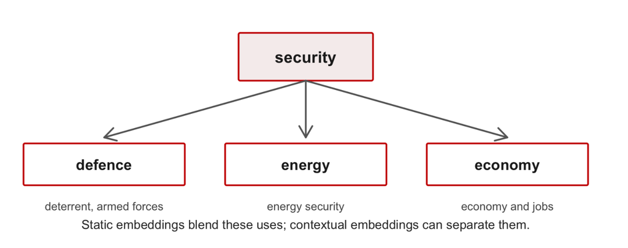

We see *security* used in defence, energy and economic contexts.

Which nearby words help us distinguish these uses?

How could we test whether these uses vary across parties or periods?

Example · security in political language.

## From topics to language representations

| Research task | Political question |
| --- | --- |
| **W8 · Topic models** | What do actors discuss, and how much? |
| **W9 · Word embeddings** | How can learned vectors describe and compare political language? |

**One-hot** gives us one coordinate per word. Different words have cosine zero.

**Embeddings** let us compare words using coordinates learned from their use.

*Dog*, *cat* and *rabbit* can be close when they appear in similar contexts.

W8: issue attention · Teaching diagram after [Hung-yi Lee](https://speech.ee.ntu.edu.tw/~hylee/index.php) · [Grimmer, Roberts & Stewart (2022), *Text as Data*, Ch. 8, p. 78](https://books.google.com.tw/books?id=dL40EAAAQBAJ&pg=PA78)

## From topics to language representations

| Research task | Political question |
| --- | --- |
| **W8 · Topic models** | What do actors discuss, and how much? |
| **W9 · Word embeddings** | How can learned vectors describe and compare political language? |

**One-hot** gives us one coordinate per word. Different words have cosine zero.

**Embeddings** let us compare words using coordinates learned from their use.

*Dog*, *cat* and *rabbit* can be close when they appear in similar contexts.

W8: issue attention · Teaching diagram after [Hung-yi Lee](https://speech.ee.ntu.edu.tw/~hylee/index.php) · [Grimmer, Roberts & Stewart (2022), *Text as Data*, Ch. 8, p. 78](https://books.google.com.tw/books?id=dL40EAAAQBAJ&pg=PA78)

## From topics to language representations

| Research task | Political question |
| --- | --- |
| **W8 · Topic models** | What do actors discuss, and how much? |
| **W9 · Word embeddings** | How can learned vectors describe and compare political language? |

**One-hot** gives us one coordinate per word. Different words have cosine zero.

**Embeddings** let us compare words using coordinates learned from their use.

*Dog*, *cat* and *rabbit* can be close when they appear in similar contexts.

W8: issue attention · Teaching diagram after [Hung-yi Lee](https://speech.ee.ntu.edu.tw/~hylee/index.php) · [Grimmer, Roberts & Stewart (2022), *Text as Data*, Ch. 8, p. 78](https://books.google.com.tw/books?id=dL40EAAAQBAJ&pg=PA78)

## From topics to language representations

| Research task | Political question |
| --- | --- |
| **W8 · Topic models** | What do actors discuss, and how much? |
| **W9 · Word embeddings** | How can learned vectors describe and compare political language? |

**One-hot** gives us one coordinate per word. Different words have cosine zero.

**Embeddings** let us compare words using coordinates learned from their use.

*Dog*, *cat* and *rabbit* can be close when they appear in similar contexts.

W8: issue attention · Teaching diagram after [Hung-yi Lee](https://speech.ee.ntu.edu.tw/~hylee/index.php) · [Grimmer, Roberts & Stewart (2022), *Text as Data*, Ch. 8, p. 78](https://books.google.com.tw/books?id=dL40EAAAQBAJ&pg=PA78)

## Learn from context and compare vectors

**Window · c = 1:** We take *cute* and *jumps* around *cat*.

**Window · c = 2:** We also include *The* and *over*.

**Learn:** CBOW (**Continuous Bag of Words**) predicts *cat* from context. Skip-gram predicts context from *cat*.

**Compare:** We use cosine to compare the directions of the learned vectors.

[Context window diagram](https://cbail.github.io/textasdata/word2vec/rmarkdown/word2vec.html#the-context-window) · [*Text as Data*, §8.2.4, p. 83](https://books.google.com.tw/books?id=dL40EAAAQBAJ&pg=PA83) · [Cosine, §7.1](https://press.princeton.edu/books/paperback/9780691207551/text-as-data)

## Learn from context and compare vectors

**Window · c = 1:** We take *cute* and *jumps* around *cat*.

**Window · c = 2:** We also include *The* and *over*.

**Learn:** CBOW (**Continuous Bag of Words**) predicts *cat* from context. Skip-gram predicts context from *cat*.

**Compare:** We use cosine to compare the directions of the learned vectors.

[Context window diagram](https://cbail.github.io/textasdata/word2vec/rmarkdown/word2vec.html#the-context-window) · [*Text as Data*, §8.2.4, p. 83](https://books.google.com.tw/books?id=dL40EAAAQBAJ&pg=PA83) · [Cosine, §7.1](https://press.princeton.edu/books/paperback/9780691207551/text-as-data)

## Learn from context and compare vectors

**Window · c = 1:** We take *cute* and *jumps* around *cat*.

**Window · c = 2:** We also include *The* and *over*.

**Learn:** CBOW (**Continuous Bag of Words**) predicts *cat* from context. Skip-gram predicts context from *cat*.

**Compare:** We use cosine to compare the directions of the learned vectors.

[Context window diagram](https://cbail.github.io/textasdata/word2vec/rmarkdown/word2vec.html#the-context-window) · [*Text as Data*, §8.2.4, p. 83](https://books.google.com.tw/books?id=dL40EAAAQBAJ&pg=PA83) · [Cosine, §7.1](https://press.princeton.edu/books/paperback/9780691207551/text-as-data)

## Learn from context and compare vectors

**Window · c = 1:** We take *cute* and *jumps* around *cat*.

**Window · c = 2:** We also include *The* and *over*.

**Learn:** CBOW (**Continuous Bag of Words**) predicts *cat* from context. Skip-gram predicts context from *cat*.

**Compare:** We use cosine to compare the directions of the learned vectors.

[Context window diagram](https://cbail.github.io/textasdata/word2vec/rmarkdown/word2vec.html#the-context-window) · [*Text as Data*, §8.2.4, p. 83](https://books.google.com.tw/books?id=dL40EAAAQBAJ&pg=PA83) · [Cosine, §7.1](https://press.princeton.edu/books/paperback/9780691207551/text-as-data)

## Training choices shape the available vectors

| Method or interface | Learning signal | Representation |
| --- | --- | --- |
| **Word2Vec** | CBOW: context → word. Skip-gram: word → context. | Static word vector |
| **GloVe** Global Vectors for Word Representation | Fit corpus-wide word co-occurrence statistics. | Static word vector |
| **fastText** | Predict from context with character n-grams. | Static word vector |
| **FlairEmbeddings** | Character language models use surrounding text. | Contextual token vector |

**Lab choice:** We use Flair’s `WordEmbeddings("glove")` to load **static GloVe**.

[Text as Data, pp. 83–84](https://books.google.com.tw/books?id=dL40EAAAQBAJ&pg=PA83) · [GloVe](https://aclanthology.org/D14-1162/) · [fastText](https://aclanthology.org/Q17-1010/) · [Flair contextual embeddings](https://flairnlp.github.io/docs/tutorial-embeddings/flair-embeddings)

## Training choices shape the available vectors

| Method or interface | Learning signal | Representation |
| --- | --- | --- |
| **Word2Vec** | CBOW: context → word. Skip-gram: word → context. | Static word vector |
| **GloVe** Global Vectors for Word Representation | Fit corpus-wide word co-occurrence statistics. | Static word vector |
| **fastText** | Predict from context with character n-grams. | Static word vector |
| **FlairEmbeddings** | Character language models use surrounding text. | Contextual token vector |

**Lab choice:** We use Flair’s `WordEmbeddings("glove")` to load **static GloVe**.

[Text as Data, pp. 83–84](https://books.google.com.tw/books?id=dL40EAAAQBAJ&pg=PA83) · [GloVe](https://aclanthology.org/D14-1162/) · [fastText](https://aclanthology.org/Q17-1010/) · [Flair contextual embeddings](https://flairnlp.github.io/docs/tutorial-embeddings/flair-embeddings)

## Training choices shape the available vectors

| Method or interface | Learning signal | Representation |
| --- | --- | --- |
| **Word2Vec** | CBOW: context → word. Skip-gram: word → context. | Static word vector |
| **GloVe** Global Vectors for Word Representation | Fit corpus-wide word co-occurrence statistics. | Static word vector |
| **fastText** | Predict from context with character n-grams. | Static word vector |
| **FlairEmbeddings** | Character language models use surrounding text. | Contextual token vector |

**Lab choice:** We use Flair’s `WordEmbeddings("glove")` to load **static GloVe**.

[Text as Data, pp. 83–84](https://books.google.com.tw/books?id=dL40EAAAQBAJ&pg=PA83) · [GloVe](https://aclanthology.org/D14-1162/) · [fastText](https://aclanthology.org/Q17-1010/) · [Flair contextual embeddings](https://flairnlp.github.io/docs/tutorial-embeddings/flair-embeddings)

## Training choices shape the available vectors

| Method or interface | Learning signal | Representation |
| --- | --- | --- |
| **Word2Vec** | CBOW: context → word. Skip-gram: word → context. | Static word vector |
| **GloVe** Global Vectors for Word Representation | Fit corpus-wide word co-occurrence statistics. | Static word vector |
| **fastText** | Predict from context with character n-grams. | Static word vector |
| **FlairEmbeddings** | Character language models use surrounding text. | Contextual token vector |

**Lab choice:** We use Flair’s `WordEmbeddings("glove")` to load **static GloVe**.

[Text as Data, pp. 83–84](https://books.google.com.tw/books?id=dL40EAAAQBAJ&pg=PA83) · [GloVe](https://aclanthology.org/D14-1162/) · [fastText](https://aclanthology.org/Q17-1010/) · [Flair contextual embeddings](https://flairnlp.github.io/docs/tutorial-embeddings/flair-embeddings)

## Training choices shape the available vectors

| Method or interface | Learning signal | Representation |
| --- | --- | --- |
| **Word2Vec** | CBOW: context → word. Skip-gram: word → context. | Static word vector |
| **GloVe** Global Vectors for Word Representation | Fit corpus-wide word co-occurrence statistics. | Static word vector |
| **fastText** | Predict from context with character n-grams. | Static word vector |
| **FlairEmbeddings** | Character language models use surrounding text. | Contextual token vector |

**Lab choice:** We use Flair’s `WordEmbeddings("glove")` to load **static GloVe**.

[Text as Data, pp. 83–84](https://books.google.com.tw/books?id=dL40EAAAQBAJ&pg=PA83) · [GloVe](https://aclanthology.org/D14-1162/) · [fastText](https://aclanthology.org/Q17-1010/) · [Flair contextual embeddings](https://flairnlp.github.io/docs/tutorial-embeddings/flair-embeddings)

## How four journal articles use embeddings

| Case | Texts | How embeddings are used |
| --- | --- | --- |
| **Case 1 · Rheault & Cochrane** | Parliamentary speech | Estimate party positions |
| **Case 2 · Rodman** | News about *equality* | Track a concept across eras |
| **Case 3 · Müller & Proksch** | European party manifestos | Find candidates for a nostalgia dictionary |
| **Case 4 · Rodriguez et al.** | U.S. Congressional Record | Compare party and gender differences in word use |

We follow four studies, asking what gets a vector and how each result helps answer the research question.

[Rheault & Cochrane (2020)](https://doi.org/10.1017/pan.2019.26) · [Rodman (2020)](https://doi.org/10.1017/pan.2019.23) · [Rodriguez et al. (2023)](https://doi.org/10.1017/S0003055422001228) · [Müller & Proksch (2024)](https://doi.org/10.1017/S0007123423000571)

## Case 1 · Party positions in parliament

**Case 1 · Party positions**

[figure not shown]

**Ludovic Rheault and Christopher Cochrane**

*Political Analysis*, 2020 · Cambridge article page

- **Background** Roll-call votes offer one way to locate parties on a political scale.
- **Question** Can speeches also reveal party positions and how they change between terms?
- **Texts** Parliamentary debates from the United States, Britain and Canada. The model represents each party in each legislative term.

[Rheault & Cochrane (2020), *Political Analysis* 28(1), 112–133](https://doi.org/10.1017/pan.2019.26) · [Author preprint](https://lrheault.github.io/downloads/rheaultcochrane2019_pa.pdf)

## Learn party embeddings with political metadata

**Case 1 · Party positions**

How embeddings are used

**1. Predict:** The model predicts *work* from context and the party-term label.

**2. Represent:** Each party in each term receives a vector, here **Labour 2005**.

**3. Project:** We use PCA to compare the party-term vectors on PC1, shown next.

[Rheault and Cochrane (2020), author preprint Figure 1, p. 8](https://lrheault.github.io/downloads/rheaultcochrane2019_pa.pdf#page=9).

## Learn party embeddings with political metadata

**Case 1 · Party positions**

How embeddings are used

**1. Predict:** The model predicts *work* from context and the party-term label.

**2. Represent:** Each party in each term receives a vector, here **Labour 2005**.

**3. Project:** We use PCA to compare the party-term vectors on PC1, shown next.

[Rheault and Cochrane (2020), author preprint Figure 1, p. 8](https://lrheault.github.io/downloads/rheaultcochrane2019_pa.pdf#page=9).

## Learn party embeddings with political metadata

**Case 1 · Party positions**

How embeddings are used

**1. Predict:** The model predicts *work* from context and the party-term label.

**2. Represent:** Each party in each term receives a vector, here **Labour 2005**.

**3. Project:** We use PCA to compare the party-term vectors on PC1, shown next.

[Rheault and Cochrane (2020), author preprint Figure 1, p. 8](https://lrheault.github.io/downloads/rheaultcochrane2019_pa.pdf#page=9).

## From party vectors to a political dimension

**Case 1 · Party positions**

**Read the axes:** We compare years horizontally and PC1 vertically. PC1 captures the greatest variation across party-term vectors.

**1920 bracket:** We see a small gap: Democrats are dashed blue; Republicans solid red.

**Answer:** By **2000**, we see the parties much farther apart on this speech-based scale.

[Rheault and Cochrane (2020), author preprint Figure 2b, p. 15](https://lrheault.github.io/downloads/rheaultcochrane2019_pa.pdf#page=16).

## From party vectors to a political dimension

**Case 1 · Party positions**

**Read the axes:** We compare years horizontally and PC1 vertically. PC1 captures the greatest variation across party-term vectors.

**1920 bracket:** We see a small gap: Democrats are dashed blue; Republicans solid red.

**Answer:** By **2000**, we see the parties much farther apart on this speech-based scale.

[Rheault and Cochrane (2020), author preprint Figure 2b, p. 15](https://lrheault.github.io/downloads/rheaultcochrane2019_pa.pdf#page=16).

## From party vectors to a political dimension

**Case 1 · Party positions**

**Read the axes:** We compare years horizontally and PC1 vertically. PC1 captures the greatest variation across party-term vectors.

**1920 bracket:** We see a small gap: Democrats are dashed blue; Republicans solid red.

**Answer:** By **2000**, we see the parties much farther apart on this speech-based scale.

[Rheault and Cochrane (2020), author preprint Figure 2b, p. 15](https://lrheault.github.io/downloads/rheaultcochrane2019_pa.pdf#page=16).

## Validate the positions outside the model

**Case 1 · Party positions**

**U.S. House** Speech-based PC1 correlates **0.918** with Voteview party averages (1921–2016).

**Next row:** We read **85.66%** agreement on party-term pair orderings.

**Answer:** We can read PC1 as a left–right scale in this overlapping period. Agreement varies across benchmarks.

[Rheault and Cochrane (2020), author preprint Table 2, p. 20](https://lrheault.github.io/downloads/rheaultcochrane2019_pa.pdf#page=21).

## Validate the positions outside the model

**Case 1 · Party positions**

**U.S. House** Speech-based PC1 correlates **0.918** with Voteview party averages (1921–2016).

**Next row:** We read **85.66%** agreement on party-term pair orderings.

**Answer:** We can read PC1 as a left–right scale in this overlapping period. Agreement varies across benchmarks.

[Rheault and Cochrane (2020), author preprint Table 2, p. 20](https://lrheault.github.io/downloads/rheaultcochrane2019_pa.pdf#page=21).

## Validate the positions outside the model

**Case 1 · Party positions**

**U.S. House** Speech-based PC1 correlates **0.918** with Voteview party averages (1921–2016).

**Next row:** We read **85.66%** agreement on party-term pair orderings.

**Answer:** We can read PC1 as a left–right scale in this overlapping period. Agreement varies across benchmarks.

[Rheault and Cochrane (2020), author preprint Table 2, p. 20](https://lrheault.github.io/downloads/rheaultcochrane2019_pa.pdf#page=21).

## Case 2 · The changing meaning of equality

**Case 2 · Semantic change**

[figure not shown]

**Emma Rodman**

*Political Analysis*, 2020 · Cambridge article page

- **Background** The word *equality* persists while debates about it change.
- **Question** Which groups and issues are associated with *equality* in different eras?
- **Texts** 3,105 news items from the New York Times Article API with *equality* in the headline, 1855–2016.

[Rodman (2020), *Political Analysis* 28(1), 87–111](https://doi.org/10.1017/pan.2019.23) · [Author manuscript](https://emmarodman.com/s/Diachronic_Word_Vectors___Political_Analysis_Final_Version.pdf)

## Newspaper contexts become historical evidence

**Case 2 · Semantic change**

How embeddings are used

| Research step | What Rodman does |
| --- | --- |
| **Collect contexts** | Use headlines, abstracts and first paragraphs when available. Group the items into seven eras. |
| **Estimate embeddings** | Compare four Word2Vec training schemes. Each produces word vectors by era. |
| **Track associations** | Compute cosine between *equality* and selected words within each era. Follow those scores across eras. |

[Rodman (2020), author manuscript §§5.2, 5.4](https://emmarodman.com/s/Diachronic_Word_Vectors___Political_Analysis_Final_Version.pdf#page=18).

## Newspaper contexts become historical evidence

**Case 2 · Semantic change**

How embeddings are used

| Research step | What Rodman does |
| --- | --- |
| **Collect contexts** | Use headlines, abstracts and first paragraphs when available. Group the items into seven eras. |
| **Estimate embeddings** | Compare four Word2Vec training schemes. Each produces word vectors by era. |
| **Track associations** | Compute cosine between *equality* and selected words within each era. Follow those scores across eras. |

[Rodman (2020), author manuscript §§5.2, 5.4](https://emmarodman.com/s/Diachronic_Word_Vectors___Political_Analysis_Final_Version.pdf#page=18).

## Newspaper contexts become historical evidence

**Case 2 · Semantic change**

How embeddings are used

| Research step | What Rodman does |
| --- | --- |
| **Collect contexts** | Use headlines, abstracts and first paragraphs when available. Group the items into seven eras. |
| **Estimate embeddings** | Compare four Word2Vec training schemes. Each produces word vectors by era. |
| **Track associations** | Compute cosine between *equality* and selected words within each era. Follow those scores across eras. |

[Rodman (2020), author manuscript §§5.2, 5.4](https://emmarodman.com/s/Diachronic_Word_Vectors___Political_Analysis_Final_Version.pdf#page=18).

## Compare time-sensitive word vectors

**Case 2 · Semantic change**

**Read the columns:** We look for lower deviations and higher correlation with the benchmark.

**Compare the row:** The chronological row has the highest correlation (**0.611**) and lowest deviations.

**Choose a model:** This model most closely matches five human-coded topic trends. Rodman then traces a new word pair.

[Rodman (2020), author manuscript Table 2, p. 25](https://emmarodman.com/s/Diachronic_Word_Vectors___Political_Analysis_Final_Version.pdf#page=25).

## Compare time-sensitive word vectors

**Case 2 · Semantic change**

**Read the columns:** We look for lower deviations and higher correlation with the benchmark.

**Compare the row:** The chronological row has the highest correlation (**0.611**) and lowest deviations.

**Choose a model:** This model most closely matches five human-coded topic trends. Rodman then traces a new word pair.

[Rodman (2020), author manuscript Table 2, p. 25](https://emmarodman.com/s/Diachronic_Word_Vectors___Political_Analysis_Final_Version.pdf#page=25).

## Compare time-sensitive word vectors

**Case 2 · Semantic change**

**Read the columns:** We look for lower deviations and higher correlation with the benchmark.

**Compare the row:** The chronological row has the highest correlation (**0.611**) and lowest deviations.

**Choose a model:** This model most closely matches five human-coded topic trends. Rodman then traces a new word pair.

[Rodman (2020), author manuscript Table 2, p. 25](https://emmarodman.com/s/Diachronic_Word_Vectors___Political_Analysis_Final_Version.pdf#page=25).

## Read semantic change with historical evidence

**Case 2 · Semantic change**

**Read:** We start with a *social*–*equality* cosine of **.48** in 1855–1879.

**Discuss:** We see a fall to **.19**, then a rebound to **.30**. Does the rebound show the earlier use continues?

[Rodman (2020), author manuscript Figure 4, p. 29](https://emmarodman.com/s/Diachronic_Word_Vectors___Political_Analysis_Final_Version.pdf#page=29).

## Read semantic change with historical evidence

**Case 2 · Semantic change**

**Read:** We start with a *social*–*equality* cosine of **.48** in 1855–1879.

**Discuss:** We see a fall to **.19**, then a rebound to **.30**. Does the rebound show the earlier use continues?

[Rodman (2020), author manuscript Figure 4, p. 29](https://emmarodman.com/s/Diachronic_Word_Vectors___Political_Analysis_Final_Version.pdf#page=29).

## Read semantic change with historical evidence

**Case 2 · Semantic change**

**Read:** We start with a *social*–*equality* cosine of **.48** in 1855–1879.

**Discuss:** We see a fall to **.19**, then a rebound to **.30**. Does the rebound show the earlier use continues?

**Check passages** Early uses could oppose interracial intimacy. Later news also connects *social equality* to social justice and institutional access.

[Rodman (2020), author manuscript Figure 4, p. 29](https://emmarodman.com/s/Diachronic_Word_Vectors___Political_Analysis_Final_Version.pdf#page=29).

## Case 3 · Nostalgia in party manifestos

**Case 3 · Nostalgia**

[figure not shown]

**Stefan Müller and Sven-Oliver Proksch**

*British Journal of Political Science*, 2024 · Cambridge article page

- **Background** A reference to the past can express praise, criticism or nostalgia.
- **Question** Do culturally conservative parties appeal more to a better past?
- **Texts** 1,648 manifestos from 24 European countries, 1946–2018.

W10 supplementary reading · [Müller & Proksch (2024), *BJPS* 54(3), 993–1005](https://doi.org/10.1017/S0007123423000571)

## From word neighbours to a nostalgia measure

**Case 3 · Nostalgia**

How embeddings are used

**1. Find candidates** Search for neighbours of seed terms in pretrained GloVe and vectors trained on manifestos.

**2. Screen candidates** Three coders review the neighbours. Accepted terms form an embeddings-based dictionary.

**3. Score manifestos** The bottom box combines both dictionaries. Flagged sentences per 1,000 become the outcome for comparing parties.

[Müller & Proksch (2024), Figure 1, panels 1–2, p. 996](https://doi.org/10.1017/S0007123423000571) · [Supplement, §B.2](https://static.cambridge.org/content/id/urn:cambridge.org:id:article:S0007123423000571/resource/name/S0007123423000571sup001.pdf)

## From word neighbours to a nostalgia measure

**Case 3 · Nostalgia**

How embeddings are used

**1. Find candidates** Search for neighbours of seed terms in pretrained GloVe and vectors trained on manifestos.

**2. Screen candidates** Three coders review the neighbours. Accepted terms form an embeddings-based dictionary.

**3. Score manifestos** The bottom box combines both dictionaries. Flagged sentences per 1,000 become the outcome for comparing parties.

[Müller & Proksch (2024), Figure 1, panels 1–2, p. 996](https://doi.org/10.1017/S0007123423000571) · [Supplement, §B.2](https://static.cambridge.org/content/id/urn:cambridge.org:id:article:S0007123423000571/resource/name/S0007123423000571sup001.pdf)

## From word neighbours to a nostalgia measure

**Case 3 · Nostalgia**

How embeddings are used

**1. Find candidates** Search for neighbours of seed terms in pretrained GloVe and vectors trained on manifestos.

**2. Screen candidates** Three coders review the neighbours. Accepted terms form an embeddings-based dictionary.

**3. Score manifestos** The bottom box combines both dictionaries. Flagged sentences per 1,000 become the outcome for comparing parties.

[Müller & Proksch (2024), Figure 1, panels 1–2, p. 996](https://doi.org/10.1017/S0007123423000571) · [Supplement, §B.2](https://static.cambridge.org/content/id/urn:cambridge.org:id:article:S0007123423000571/resource/name/S0007123423000571sup001.pdf)

## Validate the measurement before comparing parties

**Case 3 · Nostalgia**

**Methods.** We compare manifesto scores from dictionaries (M1–M4) and sentence classifiers (M5–M6), using **50 manifestos**.

**Discuss.** We compare base **.61** with expanded **.54** against two coders. Which agrees more closely?

[Müller & Proksch (2024), Figure 2, p. 998. Sentence validation on p. 997.](https://doi.org/10.1017/S0007123423000571)

## Validate the measurement before comparing parties

**Case 3 · Nostalgia**

**Methods.** We compare manifesto scores from dictionaries (M1–M4) and sentence classifiers (M5–M6), using **50 manifestos**.

**Discuss.** We compare base **.61** with expanded **.54** against two coders. Which agrees more closely?

[Müller & Proksch (2024), Figure 2, p. 998. Sentence validation on p. 997.](https://doi.org/10.1017/S0007123423000571)

## Validate the measurement before comparing parties

**Case 3 · Nostalgia**

**Methods.** We compare manifesto scores from dictionaries (M1–M4) and sentence classifiers (M5–M6), using **50 manifestos**.

**Discuss.** We compare base **.61** with expanded **.54** against two coders. Which agrees more closely?

**Check.** We see lower agreement after expansion. SVM: **.87**; DistilBERT: **.86**.

[Müller & Proksch (2024), Figure 2, p. 998. Sentence validation on p. 997.](https://doi.org/10.1017/S0007123423000571)

## Compare parties across six measures

**Case 3 · Nostalgia**

**Columns** use six standardized nostalgia scores. **M2** uses the expanded dictionary. **M4** also requires positive sentiment.

**Boxed row.** We read **.08** in M2 and **.07** in M4.

One point higher on cultural conservatism is associated with **.07–.10 SD** more manifesto nostalgia across the six models, adjusting for other variables.

[Müller & Proksch (2024), Table 1, p. 1001](https://doi.org/10.1017/S0007123423000571) · [Cultural conservatism scale, Supplement §C.6](https://static.cambridge.org/content/id/urn:cambridge.org:id:article:S0007123423000571/resource/name/S0007123423000571sup001.pdf)

## Compare parties across six measures

**Case 3 · Nostalgia**

**Columns** use six standardized nostalgia scores. **M2** uses the expanded dictionary. **M4** also requires positive sentiment.

**Boxed row.** We read **.08** in M2 and **.07** in M4.

One point higher on cultural conservatism is associated with **.07–.10 SD** more manifesto nostalgia across the six models, adjusting for other variables.

[Müller & Proksch (2024), Table 1, p. 1001](https://doi.org/10.1017/S0007123423000571) · [Cultural conservatism scale, Supplement §C.6](https://static.cambridge.org/content/id/urn:cambridge.org:id:article:S0007123423000571/resource/name/S0007123423000571sup001.pdf)

## Compare parties across six measures

**Case 3 · Nostalgia**

**Columns** use six standardized nostalgia scores. **M2** uses the expanded dictionary. **M4** also requires positive sentiment.

**Boxed row.** We read **.08** in M2 and **.07** in M4.

One point higher on cultural conservatism is associated with **.07–.10 SD** more manifesto nostalgia across the six models, adjusting for other variables.

[Müller & Proksch (2024), Table 1, p. 1001](https://doi.org/10.1017/S0007123423000571) · [Cultural conservatism scale, Supplement §C.6](https://static.cambridge.org/content/id/urn:cambridge.org:id:article:S0007123423000571/resource/name/S0007123423000571sup001.pdf)

## Same word, different contexts

**Case 4 · Method intuition · 1/3**

| The same word | Contextual clues and interpretation |
| --- | --- |
| **chips · UK use** | Ketchup, knife and fork suggest **hot fries**. |
| **chips · US use** | A bag suggests **potato crisps**. |

**Meaning here:** we compare patterns of use. These are constructed examples.

[Embedding Regression: Non-Technical Explainer, §1](https://github.com/prodriguezsosa/EmbeddingRegression/blob/main/Explainer/explainer.md#1-meaning-as-context-chips-v-crisps)

## Same word, different contexts

**Case 4 · Method intuition · 1/3**

| The same word | Contextual clues and interpretation |
| --- | --- |
| **chips · UK use** | Ketchup, knife and fork suggest **hot fries**. |
| **chips · US use** | A bag suggests **potato crisps**. |

**Meaning here:** we compare patterns of use. These are constructed examples.

[Embedding Regression: Non-Technical Explainer, §1](https://github.com/prodriguezsosa/EmbeddingRegression/blob/main/Explainer/explainer.md#1-meaning-as-context-chips-v-crisps)

## Same word, different contexts

**Case 4 · Method intuition · 1/3**

| The same word | Contextual clues and interpretation |
| --- | --- |
| **chips · UK use** | Ketchup, knife and fork suggest **hot fries**. |
| **chips · US use** | A bag suggests **potato crisps**. |

**Meaning here:** we compare patterns of use. These are constructed examples.

[Embedding Regression: Non-Technical Explainer, §1](https://github.com/prodriguezsosa/EmbeddingRegression/blob/main/Explainer/explainer.md#1-meaning-as-context-chips-v-crisps)

## A context becomes an ALC vector

**Case 4 · Method intuition · 2/3**

| Step | What the model uses |
| --- | --- |
| **1 · Look up context words** | We use their vectors from one pretrained space. |
| **2 · Average** | $\mathbf u_i=\frac{1}{\|C_i\|}\sum_{w\in C_i}\mathbf v_w$ for this occurrence’s surrounding words. |
| **3 · Calibrate** | $\mathbf y_i=A\mathbf u_i$. A learned linear transformation corrects the context average. |

**One use → one vector.** Different uses can receive different representations in the same space.

[Non-Technical Explainer, §2](https://github.com/prodriguezsosa/EmbeddingRegression/blob/main/Explainer/explainer.md#2-embeddings-as-meanings) · [Rodriguez, Spirling & Stewart (2023), ALC method](https://doi.org/10.1017/S0003055422001228)

## A context becomes an ALC vector

**Case 4 · Method intuition · 2/3**

| Step | What the model uses |
| --- | --- |
| **1 · Look up context words** | We use their vectors from one pretrained space. |
| **2 · Average** | $\mathbf u_i=\frac{1}{\|C_i\|}\sum_{w\in C_i}\mathbf v_w$ for this occurrence’s surrounding words. |
| **3 · Calibrate** | $\mathbf y_i=A\mathbf u_i$. A learned linear transformation corrects the context average. |

**One use → one vector.** Different uses can receive different representations in the same space.

[Non-Technical Explainer, §2](https://github.com/prodriguezsosa/EmbeddingRegression/blob/main/Explainer/explainer.md#2-embeddings-as-meanings) · [Rodriguez, Spirling & Stewart (2023), ALC method](https://doi.org/10.1017/S0003055422001228)

## A context becomes an ALC vector

**Case 4 · Method intuition · 2/3**

| Step | What the model uses |
| --- | --- |
| **1 · Look up context words** | We use their vectors from one pretrained space. |
| **2 · Average** | $\mathbf u_i=\frac{1}{\|C_i\|}\sum_{w\in C_i}\mathbf v_w$ for this occurrence’s surrounding words. |
| **3 · Calibrate** | $\mathbf y_i=A\mathbf u_i$. A learned linear transformation corrects the context average. |

**One use → one vector.** Different uses can receive different representations in the same space.

[Non-Technical Explainer, §2](https://github.com/prodriguezsosa/EmbeddingRegression/blob/main/Explainer/explainer.md#2-embeddings-as-meanings) · [Rodriguez, Spirling & Stewart (2023), ALC method](https://doi.org/10.1017/S0003055422001228)

## A context becomes an ALC vector

**Case 4 · Method intuition · 2/3**

| Step | What the model uses |
| --- | --- |
| **1 · Look up context words** | We use their vectors from one pretrained space. |
| **2 · Average** | $\mathbf u_i=\frac{1}{\|C_i\|}\sum_{w\in C_i}\mathbf v_w$ for this occurrence’s surrounding words. |
| **3 · Calibrate** | $\mathbf y_i=A\mathbf u_i$. A learned linear transformation corrects the context average. |

**One use → one vector.** Different uses can receive different representations in the same space.

[Non-Technical Explainer, §2](https://github.com/prodriguezsosa/EmbeddingRegression/blob/main/Explainer/explainer.md#2-embeddings-as-meanings) · [Rodriguez, Spirling & Stewart (2023), ALC method](https://doi.org/10.1017/S0003055422001228)

## The context vector is the regression outcome

**Case 4 · Method intuition · 3/3**

**Observation:** one use of chips. **Outcome:** its $D$-coordinate context vector.

$$\mathbf y_i=\boldsymbol\beta_0+UK_i\boldsymbol\beta_{UK}+\boldsymbol\epsilon_i.$$

$UK_i$: US = 0, UK = 1. Both coefficients are $D$-coordinate vectors.

**Read the result:** we use coefficient length for the size of the difference, then neighbours and passages to interpret it. Permutations assess uncertainty.

**Next:** we replace English variety with party labels and study immigration.

[Non-Technical Explainer, §§3–5](https://github.com/prodriguezsosa/EmbeddingRegression/blob/main/Explainer/explainer.md#3-embeddings-in-regression)

## The context vector is the regression outcome

**Case 4 · Method intuition · 3/3**

**Observation:** one use of chips. **Outcome:** its $D$-coordinate context vector.

$$\mathbf y_i=\boldsymbol\beta_0+UK_i\boldsymbol\beta_{UK}+\boldsymbol\epsilon_i.$$

$UK_i$: US = 0, UK = 1. Both coefficients are $D$-coordinate vectors.

**Read the result:** we use coefficient length for the size of the difference, then neighbours and passages to interpret it. Permutations assess uncertainty.

**Next:** we replace English variety with party labels and study immigration.

[Non-Technical Explainer, §§3–5](https://github.com/prodriguezsosa/EmbeddingRegression/blob/main/Explainer/explainer.md#3-embeddings-in-regression)

## The context vector is the regression outcome

**Case 4 · Method intuition · 3/3**

**Observation:** one use of chips. **Outcome:** its $D$-coordinate context vector.

$$\mathbf y_i=\boldsymbol\beta_0+UK_i\boldsymbol\beta_{UK}+\boldsymbol\epsilon_i.$$

$UK_i$: US = 0, UK = 1. Both coefficients are $D$-coordinate vectors.

**Read the result:** we use coefficient length for the size of the difference, then neighbours and passages to interpret it. Permutations assess uncertainty.

**Next:** we replace English variety with party labels and study immigration.

[Non-Technical Explainer, §§3–5](https://github.com/prodriguezsosa/EmbeddingRegression/blob/main/Explainer/explainer.md#3-embeddings-in-regression)

## The context vector is the regression outcome

**Case 4 · Method intuition · 3/3**

**Observation:** one use of chips. **Outcome:** its $D$-coordinate context vector.

$$\mathbf y_i=\boldsymbol\beta_0+UK_i\boldsymbol\beta_{UK}+\boldsymbol\epsilon_i.$$

$UK_i$: US = 0, UK = 1. Both coefficients are $D$-coordinate vectors.

**Read the result:** we use coefficient length for the size of the difference, then neighbours and passages to interpret it. Permutations assess uncertainty.

**Next:** we replace English variety with party labels and study immigration.

[Non-Technical Explainer, §§3–5](https://github.com/prodriguezsosa/EmbeddingRegression/blob/main/Explainer/explainer.md#3-embeddings-in-regression)

## Case 4 · How parties use immigration

**Case 4 · Embedding regression**

[figure not shown]

**Pedro L. Rodriguez, Arthur Spirling and Brandon M. Stewart**

*American Political Science Review*, 2023 · Cambridge article page

- **Background** Parties can mention *immigration* equally often while using it in different contexts.
- **Question** How does the use of the same word vary by party and gender?
- **Texts** U.S. Congressional Record, 111th–114th Congresses.

W9 core reading · [Rodriguez, Spirling & Stewart (2023), *APSR* 117(4), 1255–1274](https://doi.org/10.1017/S0003055422001228)

## conText: from contexts to regression

**Case 4 · Embedding regression**

**conText · Official Quick Start**

```r
fit <- conText::conText(
  immigration ~ party + gender,
  data = toks, pre_trained = E,
  transform = TRUE,
  transform_matrix = A)
```

`toks`: text + metadata. `E` and `A`: a matched pair.

**1 · One occurrence, one row.** We keep context, party and gender. $n$ uses give an $n\times D$ outcome matrix $Y$.

**2 · Build the outcome vector.** We average context-word vectors, excluding the target, then apply the common ALC transformation.

$$\mathbf u_i=\operatorname{mean}_{w\in C_i}\mathbf v_w,\qquad \mathbf y_i=A\mathbf u_i.$$

**3 · Regress all coordinates.** $R$: Republican; $M$: male.

$$\mathbf y_i=\boldsymbol\alpha+R_i\boldsymbol\beta_R+M_i\boldsymbol\beta_M+\boldsymbol\epsilon_i.$$

$\mathbf y_i$, $\boldsymbol\alpha$, $\boldsymbol\beta_R$ and $\boldsymbol\beta_M$ each have $D$ entries.

**4 · Read the coefficients.** $\boldsymbol\alpha$ (earlier $\boldsymbol\beta_0$) is the Democrat/female reference; $\boldsymbol\beta_R$ compares parties at fixed gender. We plot lengths and combine coefficients for group neighbours.

[Rodriguez, Spirling & Stewart (2023), pp. 1258–1259, 1264–1266](https://doi.org/10.1017/S0003055422001228) · [Official conText Quick Start](https://prodriguezsosa.r-universe.dev/conText/doc/quickstart.html#embedding-regression) · After-class R walkthrough

## conText: from contexts to regression

**Case 4 · Embedding regression**

**conText · Official Quick Start**

```r
fit <- conText::conText(
  immigration ~ party + gender,
  data = toks, pre_trained = E,
  transform = TRUE,
  transform_matrix = A)
```

`toks`: text + metadata. `E` and `A`: a matched pair.

**1 · One occurrence, one row.** We keep context, party and gender. $n$ uses give an $n\times D$ outcome matrix $Y$.

**2 · Build the outcome vector.** We average context-word vectors, excluding the target, then apply the common ALC transformation.

$$\mathbf u_i=\operatorname{mean}_{w\in C_i}\mathbf v_w,\qquad \mathbf y_i=A\mathbf u_i.$$

**3 · Regress all coordinates.** $R$: Republican; $M$: male.

$$\mathbf y_i=\boldsymbol\alpha+R_i\boldsymbol\beta_R+M_i\boldsymbol\beta_M+\boldsymbol\epsilon_i.$$

$\mathbf y_i$, $\boldsymbol\alpha$, $\boldsymbol\beta_R$ and $\boldsymbol\beta_M$ each have $D$ entries.

**4 · Read the coefficients.** $\boldsymbol\alpha$ (earlier $\boldsymbol\beta_0$) is the Democrat/female reference; $\boldsymbol\beta_R$ compares parties at fixed gender. We plot lengths and combine coefficients for group neighbours.

[Rodriguez, Spirling & Stewart (2023), pp. 1258–1259, 1264–1266](https://doi.org/10.1017/S0003055422001228) · [Official conText Quick Start](https://prodriguezsosa.r-universe.dev/conText/doc/quickstart.html#embedding-regression) · After-class R walkthrough

## conText: from contexts to regression

**Case 4 · Embedding regression**

**conText · Official Quick Start**

```r
fit <- conText::conText(
  immigration ~ party + gender,
  data = toks, pre_trained = E,
  transform = TRUE,
  transform_matrix = A)
```

`toks`: text + metadata. `E` and `A`: a matched pair.

**1 · One occurrence, one row.** We keep context, party and gender. $n$ uses give an $n\times D$ outcome matrix $Y$.

**2 · Build the outcome vector.** We average context-word vectors, excluding the target, then apply the common ALC transformation.

$$\mathbf u_i=\operatorname{mean}_{w\in C_i}\mathbf v_w,\qquad \mathbf y_i=A\mathbf u_i.$$

**3 · Regress all coordinates.** $R$: Republican; $M$: male.

$$\mathbf y_i=\boldsymbol\alpha+R_i\boldsymbol\beta_R+M_i\boldsymbol\beta_M+\boldsymbol\epsilon_i.$$

$\mathbf y_i$, $\boldsymbol\alpha$, $\boldsymbol\beta_R$ and $\boldsymbol\beta_M$ each have $D$ entries.

**4 · Read the coefficients.** $\boldsymbol\alpha$ (earlier $\boldsymbol\beta_0$) is the Democrat/female reference; $\boldsymbol\beta_R$ compares parties at fixed gender. We plot lengths and combine coefficients for group neighbours.

[Rodriguez, Spirling & Stewart (2023), pp. 1258–1259, 1264–1266](https://doi.org/10.1017/S0003055422001228) · [Official conText Quick Start](https://prodriguezsosa.r-universe.dev/conText/doc/quickstart.html#embedding-regression) · After-class R walkthrough

## conText: from contexts to regression

**Case 4 · Embedding regression**

**conText · Official Quick Start**

```r
fit <- conText::conText(
  immigration ~ party + gender,
  data = toks, pre_trained = E,
  transform = TRUE,
  transform_matrix = A)
```

`toks`: text + metadata. `E` and `A`: a matched pair.

**1 · One occurrence, one row.** We keep context, party and gender. $n$ uses give an $n\times D$ outcome matrix $Y$.

**2 · Build the outcome vector.** We average context-word vectors, excluding the target, then apply the common ALC transformation.

$$\mathbf u_i=\operatorname{mean}_{w\in C_i}\mathbf v_w,\qquad \mathbf y_i=A\mathbf u_i.$$

**3 · Regress all coordinates.** $R$: Republican; $M$: male.

$$\mathbf y_i=\boldsymbol\alpha+R_i\boldsymbol\beta_R+M_i\boldsymbol\beta_M+\boldsymbol\epsilon_i.$$

$\mathbf y_i$, $\boldsymbol\alpha$, $\boldsymbol\beta_R$ and $\boldsymbol\beta_M$ each have $D$ entries.

**4 · Read the coefficients.** $\boldsymbol\alpha$ (earlier $\boldsymbol\beta_0$) is the Democrat/female reference; $\boldsymbol\beta_R$ compares parties at fixed gender. We plot lengths and combine coefficients for group neighbours.

[Rodriguez, Spirling & Stewart (2023), pp. 1258–1259, 1264–1266](https://doi.org/10.1017/S0003055422001228) · [Official conText Quick Start](https://prodriguezsosa.r-universe.dev/conText/doc/quickstart.html#embedding-regression) · After-class R walkthrough

## Compare party and gender differences

**Case 4 · Embedding regression**

**Height.** The adjusted difference vector’s length: **0 = no vector difference**. Larger = greater difference. Bars: 95% bootstrap intervals.

**Compare.** For *immigration*, we read party **.175** at fixed gender and gender **.087** at fixed party. Both are vector lengths.

**Answer.** We see larger estimated usage gaps by party for all three political terms.

[Rodriguez, Spirling & Stewart (2023), Figure 5](https://doi.org/10.1017/S0003055422001228) · [Supplement Table J.4](https://static.cambridge.org/content/id/urn:cambridge.org:id:article:S0003055422001228/resource/name/S0003055422001228sup001.pdf#page=25)

## Compare party and gender differences

**Case 4 · Embedding regression**

**Height.** The adjusted difference vector’s length: **0 = no vector difference**. Larger = greater difference. Bars: 95% bootstrap intervals.

**Compare.** For *immigration*, we read party **.175** at fixed gender and gender **.087** at fixed party. Both are vector lengths.

**Answer.** We see larger estimated usage gaps by party for all three political terms.

[Rodriguez, Spirling & Stewart (2023), Figure 5](https://doi.org/10.1017/S0003055422001228) · [Supplement Table J.4](https://static.cambridge.org/content/id/urn:cambridge.org:id:article:S0003055422001228/resource/name/S0003055422001228sup001.pdf#page=25)

## Compare party and gender differences

**Case 4 · Embedding regression**

**Height.** The adjusted difference vector’s length: **0 = no vector difference**. Larger = greater difference. Bars: 95% bootstrap intervals.

**Compare.** For *immigration*, we read party **.175** at fixed gender and gender **.087** at fixed party. Both are vector lengths.

**Answer.** We see larger estimated usage gaps by party for all three political terms.

[Rodriguez, Spirling & Stewart (2023), Figure 5](https://doi.org/10.1017/S0003055422001228) · [Supplement Table J.4](https://static.cambridge.org/content/id/urn:cambridge.org:id:article:S0003055422001228/resource/name/S0003055422001228sup001.pdf#page=25)

## What do group differences contain?

**Case 4 · Embedding regression**

**Read each row.** Each row lists the ten words closest by cosine to that party’s estimated *immigration* vector.

**Interpret the boxes.** We see **changing the system** near Democrats and **enforcing existing law** near Republicans.

We also see *enact* and *legislation* in both rows. Next, we check the passages.

[Rodriguez, Spirling & Stewart (2023), Table 4, p. 1267](https://doi.org/10.1017/S0003055422001228)

## What do group differences contain?

**Case 4 · Embedding regression**

**Read each row.** Each row lists the ten words closest by cosine to that party’s estimated *immigration* vector.

**Interpret the boxes.** We see **changing the system** near Democrats and **enforcing existing law** near Republicans.

We also see *enact* and *legislation* in both rows. Next, we check the passages.

[Rodriguez, Spirling & Stewart (2023), Table 4, p. 1267](https://doi.org/10.1017/S0003055422001228)

## What do group differences contain?

**Case 4 · Embedding regression**

**Read each row.** Each row lists the ten words closest by cosine to that party’s estimated *immigration* vector.

**Interpret the boxes.** We see **changing the system** near Democrats and **enforcing existing law** near Republicans.

We also see *enact* and *legislation* in both rows. Next, we check the passages.

[Rodriguez, Spirling & Stewart (2023), Table 4, p. 1267](https://doi.org/10.1017/S0003055422001228)

## Return to the original contexts

**Case 4 · Embedding regression**

**Read the party labels.** We read passages close to each party’s estimated vector.

**Answer.** We see **reform** in the Democratic passage and **enforcement** in the Republican passage.

**Scope.** These passages illustrate the contrast. To estimate frequency, we need a broader sample.

[Rodriguez, Spirling & Stewart (2023), Table 5, p. 1267](https://doi.org/10.1017/S0003055422001228)

## Return to the original contexts

**Case 4 · Embedding regression**

**Read the party labels.** We read passages close to each party’s estimated vector.

**Answer.** We see **reform** in the Democratic passage and **enforcement** in the Republican passage.

**Scope.** These passages illustrate the contrast. To estimate frequency, we need a broader sample.

[Rodriguez, Spirling & Stewart (2023), Table 5, p. 1267](https://doi.org/10.1017/S0003055422001228)

## Return to the original contexts

**Case 4 · Embedding regression**

**Read the party labels.** We read passages close to each party’s estimated vector.

**Answer.** We see **reform** in the Democratic passage and **enforcement** in the Republican passage.

**Scope.** These passages illustrate the contrast. To estimate frequency, we need a broader sample.

[Rodriguez, Spirling & Stewart (2023), Table 5, p. 1267](https://doi.org/10.1017/S0003055422001228)

## Embedding regression beyond English

**Case 4 · Multilingual extension**

[figure not shown]

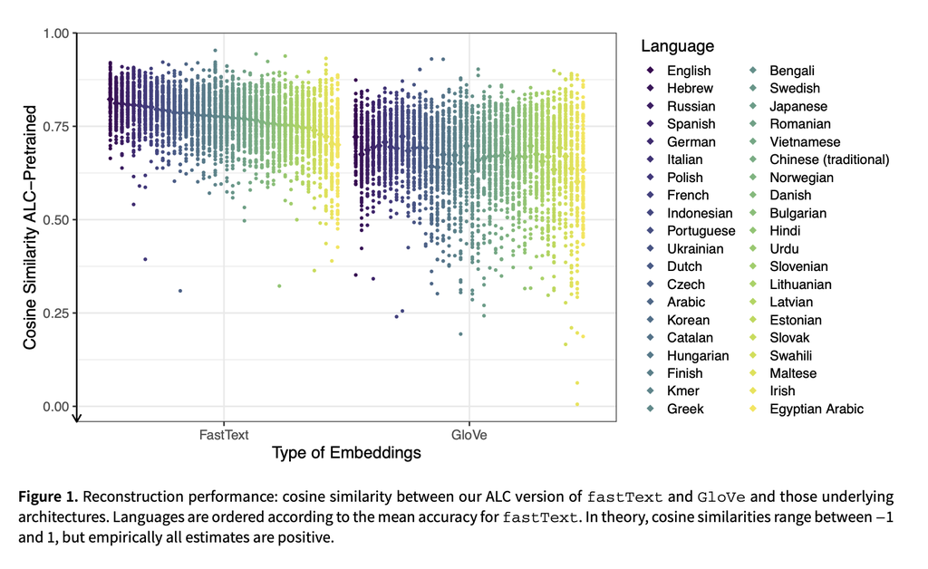

We compare ALC estimates with pretrained vectors within each language.

[Wirsching et al. (2025), *Political Analysis*, Figure 1, p. 159](https://doi.org/10.1017/pan.2024.17)

## Four studies using embedding regression

**Case 4 · Further applications**

**Gonthier (2025) · SPSR**  
French *peuple* across ideological groups.

**Karell & Sachs (2023) · Socius**  
Minority-group language before/after a signal.

**Van Matre et al. (2026) · PSJ**  
Climate frames by party and congressional term.

**Kim & Kesari (2021) · JOTS**  
“Chinese virus”: hate/counterhate and time.

Study notes and DOI links · W10 comparison: supplement

## Four studies using embedding regression

**Case 4 · Further applications**

**Gonthier (2025) · SPSR**  
French *peuple* across ideological groups.

**Karell & Sachs (2023) · Socius**  
Minority-group language before/after a signal.

**Van Matre et al. (2026) · PSJ**  
Climate frames by party and congressional term.

**Kim & Kesari (2021) · JOTS**  
“Chinese virus”: hate/counterhate and time.

Study notes and DOI links · W10 comparison: supplement

## Four studies using embedding regression

**Case 4 · Further applications**

**Gonthier (2025) · SPSR**  
French *peuple* across ideological groups.

**Karell & Sachs (2023) · Socius**  
Minority-group language before/after a signal.

**Van Matre et al. (2026) · PSJ**  
Climate frames by party and congressional term.

**Kim & Kesari (2021) · JOTS**  
“Chinese virus”: hate/counterhate and time.

Study notes and DOI links · W10 comparison: supplement

## Four studies using embedding regression

**Case 4 · Further applications**

**Gonthier (2025) · SPSR**  
French *peuple* across ideological groups.

**Karell & Sachs (2023) · Socius**  
Minority-group language before/after a signal.

**Van Matre et al. (2026) · PSJ**  
Climate frames by party and congressional term.

**Kim & Kesari (2021) · JOTS**  
“Chinese virus”: hate/counterhate and time.

Study notes and DOI links · W10 comparison: supplement

## Lab guide · Know the workflow before the break

**Guide 1/3 · Goal and plan · 17:31–17:32**

**Goal:** We learn what a vector represents, how to compare it and how to check our interpretation.

| Classroom block | What the vector represents | Short Check |
| --- | --- | --- |
| **17:40–17:55 · Our 2024 Lab** | A static vector for each word type; then a PCA projection. | **E06:** matrix units and identical security vectors. **PCA Check:** what the map leaves out. |
| **17:55–18:10 · conText** | A vector for each occurrence’s context; then a conditional group comparison. | **E04:** unit → word/context evidence → party coefficient. |

We read a short Code example, examine its Output and answer a Check. The Lab includes the full runnable steps.

Our 2024 Lab with figures · [conText Quick Start](https://github.com/prodriguezsosa/conText/blob/master/vignettes/quickstart.md) · Lab purpose and workflow

## Lab guide · Know the workflow before the break

**Guide 2/3 · Our 2024 Flair/PCA workflow · 17:32–17:33:30**

| Step | Read the input and output | What it tells us |
| --- | --- | --- |
| **1 · Load** | R/Python environment + cached GloVe → **100 coordinates**. | We load a trained model. |
| **2 · Get vectors** | Eleven listed words → **11 × 100** matrix. | One row per token in the word list. |
| **3 · Compare security** | Three sentences → **3 × 100** security matrix; cosine **1**. | Static lookup returns the same word-type vector. |
| **4 · Read PCA** | The same eleven vectors → **table + 2D + 3D**; PC1/2 retain **38.24%**. | We distinguish this projection from full-space cosine. |

**E06:** explain the two matrix sizes and cosine 1. **PCA Check:** does proximity on the map guarantee full-space similarity?

Our 2024 Lab with figures · [conText Quick Start](https://github.com/prodriguezsosa/conText/blob/master/vignettes/quickstart.md) · Lab purpose and workflow

## Lab guide · Know the workflow before the break

**Guide 3/3 · conText workflow · 17:33:30–17:35**

| Step | Read the input and output |
| --- | --- |
| **C00 · Inputs** | **400 texts** + **E: 500 × 300** word vectors + matched **A: 300 × 300**. |
| **C01 · Contexts** | Each immigration occurrence and its metadata → **924 context rows**. |
| **C02 · ALC** | Surrounding words + E/A → **924 × 300** context vectors → **2 × 300** party means. |
| **C03–04 · Interpret** | We check our reading of nearby words against retrieved context words. |
| **C05 · Regression** | We return to occurrences and compare **R with D, holding gender fixed**. |

**E04:** How do we connect an observation, its word/context evidence and the party coefficient? Regression adds adjustment for gender.

**Next:** we take five minutes and begin Flair at **17:40**.

Our 2024 Lab with figures · [conText Quick Start](https://github.com/prodriguezsosa/conText/blob/master/vignettes/quickstart.md) · Lab purpose and workflow

## Five-minute break

We return at 17:40 for Flair preparation, with the Lab handout beside the slides.

**30-minute Lab:** Our 2024 Flair exercise and plots (15 min) → conText Quick Start (15 min).

We read each core call, examine its output and answer a short Check.

**After class:** full PCA computation and advanced extensions.

conText classroom script · W9 lab handout

## Lab · Prepare Flair

**17:40–17:42.** We check the R/Python connection and cached model.

Before class, we prepare Python, packages and GloVe with Lab F00. From the course root:

```r
source("W9/lab/flair/flair_prepare.R")
```

If R is unavailable, we use the Python route. Installation and downloads happen before class.

R preparation · Python preparation · Before-class F00

## Lab · Flair 1: Load the model

**17:42–17:44.** We load GloVe in R or Python and check its dimensions.

We stay in the same session. `glove_path` points to the cached model file.

```r
embedding <- WordEmbeddings(glove_path)
print(embedding$embedding_length)
```

R Step 1 · Python Step 1 · [Flair classic embeddings](https://flairnlp.github.io/docs/tutorial-embeddings/classic-word-embeddings)

## Lab · Flair 2: Get word vectors

**17:44–17:47.** We create a Sentence, attach embeddings and read the coordinates. Python follows the same steps.

```r
word_list <- paste("King Queen man woman Paris London",
  "apple orange Taiwan Dublin Bamberg")
word_sentence <- Sentence(word_list)
embedding$embed(word_sentence)
word_vectors <- do.call(rbind, lapply(word_sentence$tokens,
  function(token) as.numeric(token$embedding$tolist())))
print(dim(word_vectors))
```

R Step 2 · Python Step 2 · Python preparation if needed

## Lab · Flair 3: Compare security

**17:47–17:52.** We compare three occurrences, then explain the result in E06 at 17:50–17:52.

We use the three sentences from the Lab. This call attaches vectors to their tokens.

```r
embedding$embed(sentences)
```

R Step 3 · Python Step 3 · E06

## Lab · PCA: Read the 2024 word-vector map

**17:52–17:55.** We read the 2D/3D figures now and leave the full computation for after class.

**Core call · full steps are in the Lab.**

```r
pca_result <- prcomp(word_vectors,
  center = TRUE, scale. = TRUE)
round(pca_result$x[1:3, 1:2], 2)
```

Our 2024 Lab · Same-run 3D figure · PCA figures and full calculation

## Lab · C00: Text, vectors and a matched transformation

**17:55–17:58.** We now use conText, starting with its texts, vectors and matching transformation.

**Core call · full steps are in the Lab.**

```r
print(c(documents = ndoc(cr_sample_corpus)))
print(rbind(E = dim(cr_glove_subset),
  A = dim(cr_transform)))
```

Core call and full step · Recorded output · [Official Quick Start](https://github.com/prodriguezsosa/conText/blob/master/vignettes/quickstart.md)

## Lab · C01: Keep one occurrence per row

**17:58–18:00.** We extract immigration contexts and keep their party and gender labels.

**Core call · full steps are in the Lab.**

```r
immig_toks <- tokens_context(toks_nostop_feats,
  pattern = "immigration", window = 6L, valuetype = "fixed",
  rm_keyword = TRUE)
```

Core call and full step · Recorded output · [Official Quick Start](https://github.com/prodriguezsosa/conText/blob/master/vignettes/quickstart.md)

## Lab · C02: Turn contexts into ALC vectors

**18:00–18:03.** We turn each context into an ALC vector, then average by party.

**Core call · full steps are in the Lab.**

```r
immig_dfm <- dfm(immig_toks)
immig_dem <- dem(immig_dfm, pre_trained = cr_glove_subset,
  transform = TRUE, transform_matrix = cr_transform,
  verbose = FALSE)
immig_wv_party <- dem_group(immig_dem,
  groups = immig_dem@docvars$party)
```

Core call and full step · Recorded output · [Official Quick Start](https://github.com/prodriguezsosa/conText/blob/master/vignettes/quickstart.md)

## Lab · C03: Read the nearby words

**18:03–18:05.** We use nearby words to interpret the party averages.

**Core call · full steps are in the Lab.**

```r
immig_nns <- nns(immig_wv_party,
  pre_trained = cr_glove_subset, N = 3,
  candidates = immig_wv_party@features, as_list = FALSE)
```

Core call and full step · Recorded output · [Official Quick Start](https://github.com/prodriguezsosa/conText/blob/master/vignettes/quickstart.md)

## Lab · C04: Read the nearby contexts

**18:05–18:07.** We check that interpretation against the nearby contexts.

**Core call · full steps are in the Lab.**

```r
immig_ncs <- ncs(immig_wv_party, contexts_dem = immig_dem,
  contexts = immig_toks, N = 1, as_list = FALSE)
```

Core call and full step · Recorded output · [Official Quick Start](https://github.com/prodriguezsosa/conText/blob/master/vignettes/quickstart.md)

## Lab · C05: Introduce embedding regression

**18:07–18:10.** We return to occurrences and compare parties while holding gender fixed.

**Core call · full steps are in the Lab.**

```r
set.seed(2021L)
fit <- conText(immigration ~ party + gender,
  data = toks_nostop_feats, pre_trained = cr_glove_subset,
  transform = TRUE, transform_matrix = cr_transform,
  jackknife = FALSE, permute = TRUE,
  num_permutations = 100, window = 6L,
  valuetype = "fixed", verbose = FALSE)
```

Core call and full step · Recorded output · [Official Quick Start](https://github.com/prodriguezsosa/conText/blob/master/vignettes/quickstart.md)

## Design an embedding study in one paragraph

1. We start with a political question and the **unit** that receives a vector.
2. We choose the corpus, representation and comparison for that question.
3. We identify evidence that could change our interpretation.

**Our design.** How might we compare a policy term across parties, periods or legislative settings?

[Text as Data, §§8.2 and 8.4](https://press.princeton.edu/books/hardcover/9780691207544/text-as-data) · W9 case guide

## Readings and classroom materials

**Concepts and demonstrations**

- Grimmer, Roberts & Stewart (2022), *Text as Data*, Ch. 8. Ch. 7 covers similarity and TF–IDF.
- Schoonvelde (2026), ESS Day 3, *Comparing Representations*.

**Assigned studies**

- Bischof & Senninger (2018), campaign language and political knowledge.
- Rodriguez & Spirling (2022), evaluating word embeddings.
- Rodriguez, Spirling & Stewart (2023), embedding regression.

Reading guide · Book and ESS crosswalk · W9 lab · Supplement · After-class lab

## References

### W9 assigned readings

**Bischof & Senninger (2018)** · *EJPR* · [DOI](https://doi.org/10.1111/1475-6765.12235)  
Simple Politics for the People? Complexity in Campaign Messages and Political Knowledge

**Rodriguez & Spirling (2022)** · *JOP* · [DOI](https://doi.org/10.1086/715162)  
Word Embeddings: What Works, What Doesn’t, and How to Tell the Difference for Applied Research

**Rodriguez, Spirling & Stewart (2023)** · *APSR* · Case 4 · [DOI](https://doi.org/10.1017/S0003055422001228)  
Embedding Regression: Models for Context-Specific Description and Inference

### W9 optional reading

**Wirsching et al. (2025)** · *Political Analysis* · [DOI](https://doi.org/10.1017/pan.2024.17)  
Multilanguage Word Embeddings for Social Scientists: Estimation, Inference, and Validation Resources for 157 Languages

### Additional W9 cases

**Rheault & Cochrane (2020)** · *Political Analysis* · Case 1 · [DOI](https://doi.org/10.1017/pan.2019.26)  
Word Embeddings for the Analysis of Ideological Placement in Parliamentary Corpora

**Rodman (2020)** · *Political Analysis* · Case 2 · [DOI](https://doi.org/10.1017/pan.2019.23)  
A Timely Intervention: Tracking the Changing Meanings of Political Concepts with Word Vectors

### W10 optional readings used in W9

**Müller & Proksch (2024)** · *BJPS* · Case 3 · [DOI](https://doi.org/10.1017/S0007123423000571)  
Nostalgia in European Party Politics: A Text-Based Measurement Approach

**Widmann & Wich (2023)** · *Political Analysis* · W10 comparison · [DOI](https://doi.org/10.1017/pan.2022.15)  
Creating and Comparing Dictionary, Word Embedding, and Transformer-Based Models to Measure Discrete Emotions in German Political Text

Four ER applications and DOI links · W9 reading guide · W9 case guide

## Learn coordinates by predicting words

**Input** One active vocabulary position.

**Hidden** Learned coordinates $z_1,z_2$.

**Output** Next-word probabilities; target: *attends*.

**Update** Error updates the connection weights.

The plotted positions are a teaching illustration.

Flair token extraction

## Learn coordinates by predicting words

**Input** One active vocabulary position.

**Hidden** Learned coordinates $z_1,z_2$.

**Output** Next-word probabilities; target: *attends*.

**Update** Error updates the connection weights.

The plotted positions are a teaching illustration.

Flair token extraction

## Learn coordinates by predicting words

**Input** One active vocabulary position.

**Hidden** Learned coordinates $z_1,z_2$.

**Output** Next-word probabilities; target: *attends*.

**Update** Error updates the connection weights.

The plotted positions are a teaching illustration.

Flair token extraction

## Learn coordinates by predicting words

**Input** One active vocabulary position.

**Hidden** Learned coordinates $z_1,z_2$.

**Output** Next-word probabilities; target: *attends*.

**Update** Error updates the connection weights.

The plotted positions are a teaching illustration.

Flair token extraction

## Related words in prediction

**The book’s movie review example**

We train a classifier on labeled reviews that use **great**.

A new review uses **fantastic**. What can we carry over if the two words have related vectors?

We can predict using word similarities learned from the training corpus.

[Grimmer, Roberts & Stewart (2022), §8.1, p. 80](https://books.google.com.tw/books?id=dL40EAAAQBAJ&pg=PA80).

## What does each row represent?

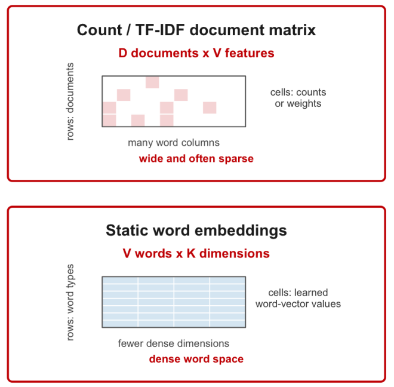

**Document counts** give each speech a row of feature counts.

**Static word embeddings** give each word type a row of learned coordinates.

Which rows do we compare for two speeches? For two words?

Schoonvelde (2026), *Comparing Representations*, ESS Day 3, original p. 6, document and word panels. ESS materials and page map

## Compute cosine for two speeches

| Speech | security | forces | energy |
| --- | --- | --- | --- |
| Defence | 1 | 1 | 0 |
| Energy | 1 | 0 | 1 |

$$\cos(\mathbf{a},\mathbf{b})=\frac{\mathbf{a}\cdot\mathbf{b}}{\lVert\mathbf{a}\rVert\lVert\mathbf{b}\rVert}=\frac{1}{\sqrt{2}\sqrt{2}}=0.50$$

Both speeches contain *security*. Each also contains a different feature.

Schoonvelde (2026), ESS Day 3, numerical example from original p. 10. ESS materials and page map

## Average word vectors to represent a document

We average the available token vectors one coordinate at a time.

| Token | Coordinate 1 | Coordinate 2 |
| --- | --- | --- |
| first token | 1 | 0 |
| second token | 0 | 2 |
| **document mean** | **0.5** | **1.0** |

Repeated tokens contribute repeatedly to the simple average. The resulting vector summarizes the document.

[Grimmer, Roberts & Stewart (2022), §8.3, pp. 86–87](https://books.google.com.tw/books?id=dL40EAAAQBAJ&pg=PA86). Two-coordinate arithmetic constructed for W9.

## The PCA map changes the nearest words

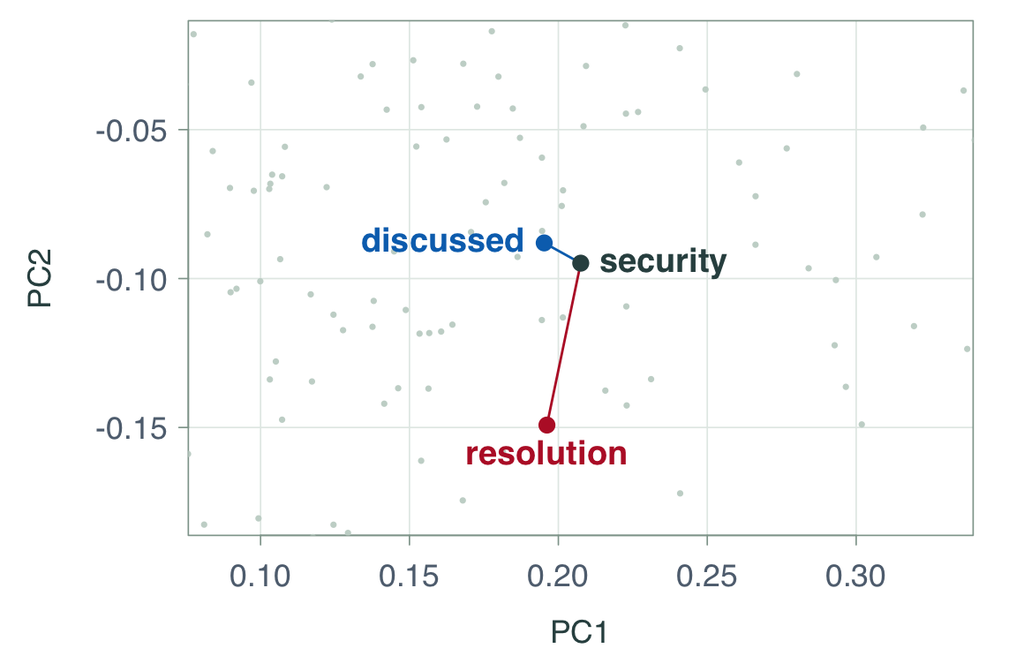

On the **two-dimensional map**, *discussed* is closest to *security*.

Across all **30 dimensions**, *resolution* has the highest cosine with *security* (0.661).

PC1 and PC2 retain **9.54%** of the variance in this model’s unit vectors.

W9 teaching GloVe vectors · ESS Day 3, p. 19 · R05 PCA check · Plot source

## How did presidents talk about manufacturing?

**U.S. State of the Union addresses**

The book compares **1900–1959** with **1960–2016**. It finds 53 mentions of *manufacturing* across the two periods.

1. Collect the words around each mention.
2. Represent those words with pretrained embeddings.
3. Average the context word vectors within each period and apply a learned linear transform to each average.

This à la carte procedure gives one **300-dimensional vector** for *manufacturing* per period.

[Grimmer, Roberts & Stewart (2022), *Text as Data*, §8.2.7, p. 85](https://books.google.com.tw/books?id=dL40EAAAQBAJ&pg=PA85)

## The neighbours of manufacturing change over time

Cosine distance ranks other words by their proximity to each period’s *manufacturing* vector.

| 1900–1959 | 1960–2016 |
| --- | --- |
| `exportation` | `retooling` |
| `oil-related` | `jobs` |
| `energy-intensive` | `offshoring` |

The selected neighbours associate the term with trade and energy in the earlier period and restructuring and employment in the later one.

Selected reported neighbours from [Grimmer, Roberts & Stewart (2022), *Text as Data*, §8.2.7, p. 85](https://books.google.com.tw/books?id=dL40EAAAQBAJ&pg=PA85) and [p. 86](https://books.google.com.tw/books?id=dL40EAAAQBAJ&pg=PA86).

## Validate the representation for its use

| Evaluation | Question |
| --- | --- |
| Intrinsic | Do vector relationships agree with an external judgment about words? |
| Extrinsic | Do the vectors help on a downstream task, such as predicting labels? |
| Substantive | Does the comparison support the interpretation required by the research question? |

For *manufacturing*, which passages could we read to check the period contrast?

[Grimmer, Roberts & Stewart (2022), §8.4, p. 87](https://books.google.com.tw/books?id=dL40EAAAQBAJ&pg=PA87).

## W10 comparison: emotion measurement

**W10 · Optional comparison**

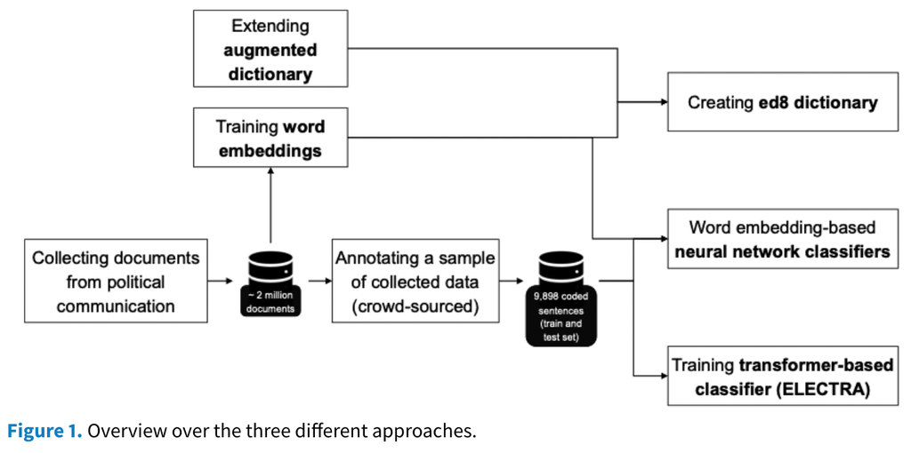

**Question** Which models distinguish eight emotional appeals in German political text?

**Data** 9,898 annotated sentences from parliamentary speeches and party Facebook posts.

**Routes** Neighbours expand ed8; word2vec sentence averages feed a neural network. ELECTRA is fine-tuned on annotated sentences.

W10 optional comparison reading · [Widmann & Wich (2023), Figure 1, pp. 629–632](https://doi.org/10.1017/pan.2022.15) · Journal article heading

## Test predictions against human coding

**W10 · Optional comparison**

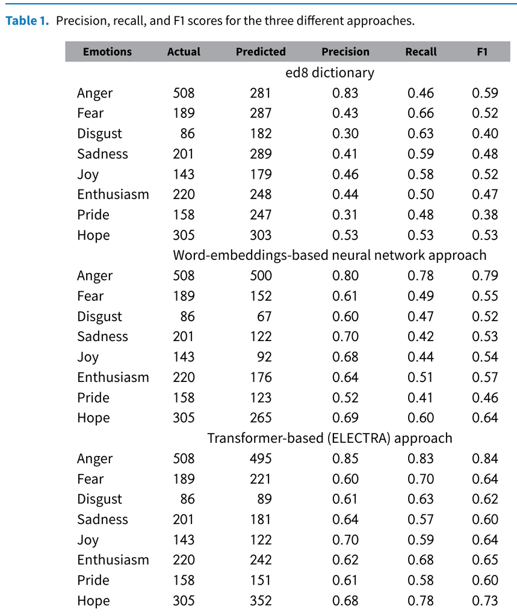

**F1 in the held-out sentences**

| Model | Anger | Fear |
| --- | --- | --- |
| ed8 | .59 | .52 |
| word2vec + NN | .79 | .55 |
| ELECTRA | .84 | .64 |

The authors also tested a new random sample of sentences.

[Widmann & Wich (2023), Table 1, p. 634. Robustness checks on pp. 635–638.](https://doi.org/10.1017/pan.2022.15)

## Four ways embeddings support an answer

| Research goal | What gets a vector | How the study answers |
| --- | --- | --- |
| **1 · Locate parties** | A party in a legislative term | PC1 gives a speech scale. Voteview helps interpret it. |
| **2 · Track meaning** | A word in a historical period | Cosine tracks associations. News passages show what changed. |
| **3 · Measure nostalgia** | A seed term or candidate term | Neighbours expand the dictionary. Its scores enter a regression. |
| **4 · Compare word use** | One use of a target word | Regression estimates the gap. Neighbours and passages explain it. |

[Rheault & Cochrane (2020)](https://doi.org/10.1017/pan.2019.26) · [Rodman (2020)](https://doi.org/10.1017/pan.2019.23) · [Rodriguez et al. (2023)](https://doi.org/10.1017/S0003055422001228) · [Müller & Proksch (2024)](https://doi.org/10.1017/S0007123423000571)

## Evaluate embeddings for the task

| Use of the vectors | What to check |
| --- | --- |
| Features for prediction | Performance on held-out texts or a new corpus |
| Measures of political language | Human judgments, original passages and appropriate benchmarks |
| Comparisons across corpora | Domain, vocabulary coverage and stability across model settings |
| Social associations | Target and attribute sets, source-corpus composition and sensitivity of the comparison |

Rodriguez and Spirling compare window sizes, dimensions, training runs and human judgments of word associations.

[Rodriguez & Spirling (2022), pp. 105–108, 112–113](https://doi.org/10.1086/715162) · [Text as Data, §8.4](https://press.princeton.edu/books/hardcover/9780691207544/text-as-data)

## Campaign language and political knowledge

**Question.** Are voters closer to expert placements when parties use simpler manifestos?

- Bischof and Senninger compare German and Austrian manifestos using **LIX**.
- They compare voters’ left–right placements of parties with expert placements.
- Simpler manifestos are associated with smaller placement gaps.

[Bischof & Senninger (2018), pp. 477–481 and 486–490](https://doi.org/10.1111/1475-6765.12235)

## LIX and Flesch score text in opposite directions

| Measure | What it uses | Higher score |
| --- | --- | --- |
| LIX | Mean words per sentence + percentage of long words | More complex |
| Flesch Reading Ease | Words per sentence and syllables per word | Easier to read |

A sentence split can change both scores while the policy proposal stays the same.

[Bischof & Senninger (2018), p. 479](https://doi.org/10.1111/1475-6765.12235) · [quanteda readability reference](https://quanteda.io/reference/textstat_readability.html)